# Networks: Project 3

Dmitry Donetskov

# Problem Statement

Make a CUG test on a network of your choice.

# Network

The data is the network of American football games between Division IA colleges during regular season Fall 2000, as compiled by M. Girvan and M. Newman (Girvan and Newman (2002)). To quote

> The network we look at is a representation of the schedule of Division I games for the 2000 season: vertices in the graph represent teams (identified by their college names) and edges represent regular-season games between the two teams they connect. What makes this network interesting is that it incorporates a known community structure. The teams are divided into conferences containing around 8–12 teams each. Games are more frequent between members of the same conference than between members of different conferences, with teams playing an average of about seven intraconference games and four interconference games in the 2000 season.

By description of the network we can assume there are components in it which have more connections within and between them.

Let’s check with CUG

## Basic Network Characteristics

| Property | Value |
| --- | --- |
| Vertices | 115 |
| Edges | 613 |
| Directed | No |
| Weighted | No |
| Average degree | 10.7 |
| Diameter | 4 |
| Acyclic | No |
| Edge density | 0.0935163996948894 |
| Average Path Length | 2.50816170861937 |
| Transitivity (global) | 0.407239819004525 |

The network coloured according to which division each club belongs to.

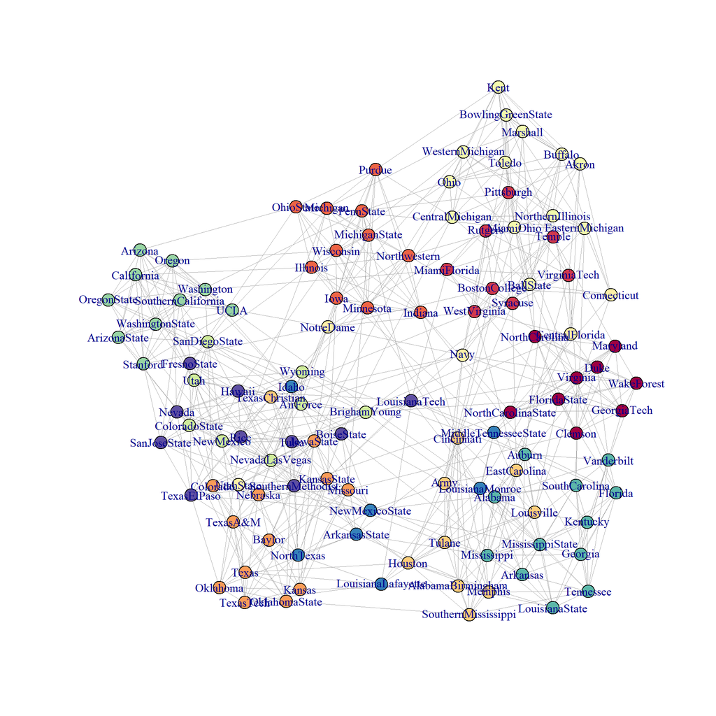

```r
pal = colorRampPalette(brewer.pal(11,"Spectral"))(length(unique(V(net)$value)))
node_colors  <- pal[V(net)$value + 1]
V(net)$color <- node_colors

coords_fr = layout.fruchterman.reingold(net, weights=E(net)$weight)

# igraph plot options
igraph.options(vertex.size=8, edge.width=0.75)
plot(net, layout=coords_fr, vertex.size = 5, vertex.color=V(net)$color)
```

# Analysis

```r
library(statnet)

# converting from the 'igraph' format to the 'network' one
net2 <- network(as.matrix(as_adjacency_matrix(net, type="both", names=TRUE, sparse=FALSE)),
                matrix.type="adjacency", directed=FALSE)

rSize  <- cug.test(net2, centralization, FUN.arg=list(FUN=betweenness), mode="graph", cmode="size")
rEdges <- cug.test(net2, centralization, FUN.arg=list(FUN=betweenness), mode="graph", cmode="edges")
rDyad  <- cug.test(net2, centralization, FUN.arg=list(FUN=betweenness), mode="graph", cmode="dyad.census")

#names(rSize)
#rSize

# Aggregate results
Betweenness <- c(rSize$obs.stat, rEdges$obs.stat, rDyad$obs.stat)
PctGreater  <- c(rSize$pgteobs,  rEdges$pgteobs,  rDyad$pgteobs)
PctLess     <- c(rSize$plteobs,  rEdges$plteobs,  rDyad$plteobs)
report      <- cbind(Betweenness, PctGreater, PctLess)
rownames(report) <- c("Size","Edges","Dyads")
```

```r
report
```

```
##       Betweenness PctGreater PctLess
## Size   0.02036347      0.000   1.000
## Edges  0.02036347      0.690   0.310
## Dyads  0.02036347      0.717   0.283
```

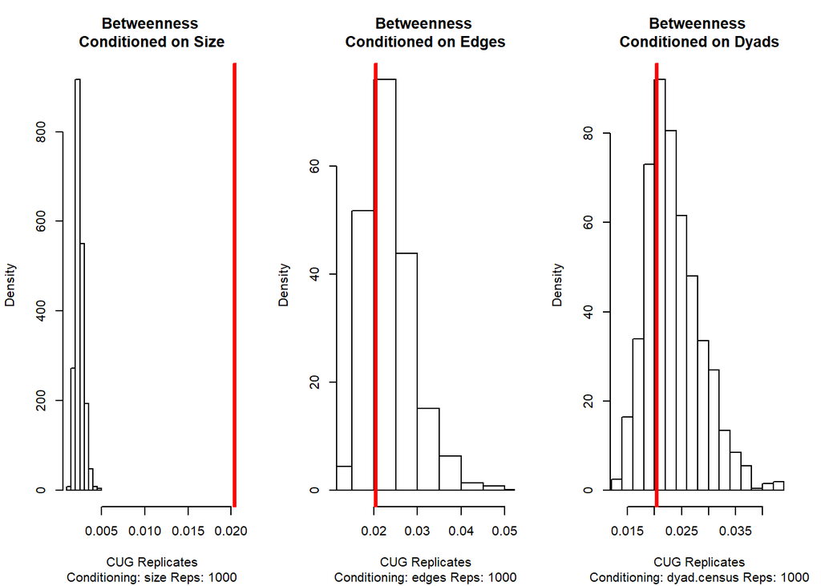

```r
par(mfrow=c(1,3))
plot(rSize,  main="Betweenness \nConditioned on Size" )
plot(rEdges, main="Betweenness \nConditioned on Edges" )
plot(rDyad,  main="Betweenness \nConditioned on Dyads" )
```

```r
par(mfrow=c(1,1))
```

# Findings

The CUG analysis shows that the network has unusually high level of centralization for the given number of nodes and that relfects the nature of network (that connections between teams within divisions are more likely than between teams from different divisions). But this level of centralization is not uncommon (and rather a bit low) for the given number of edges and the given distribution of dyads.

# References

Girvan, M., and M. E. J. Newman. 2002. “Community Structure in Social and Biological Networks.” *Proceedings of the National Academy of Sciences* 99 (12). National Academy of Sciences:7821–6. https://doi.org/10.1073/pnas.122653799.